# Reproducible Research: Peer Assessment 1

## Loading and preprocessing the data

```r
activity<-read.csv('activity.csv',header=T,stringsAsFactors = F)
activity$date<-as.Date(activity$date,"%Y-%m-%d")
```

## What is mean total number of steps taken per day?

1. Make a histogram of the total number of steps taken each day

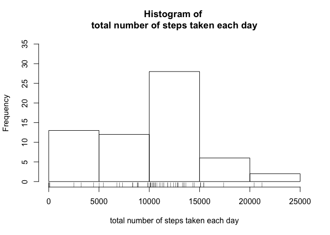

```r
library(dplyr, warn.conflicts=FALSE)
activity_dailytotal<- activity %>%
                      group_by(date) %>%
                      summarise(total = sum(steps,na.rm=TRUE)) %>%
                      ungroup(activity) %>%
                      na.omit

hist(activity_dailytotal$total,xlab = 'total number of steps taken each day',main = 'Histogram of \ntotal number of steps taken each day',ylim = c(0,35))
rug(activity_dailytotal$total)
```

2. Calculate and report the **mean** and **median** total number of steps taken per day

```r
summary(activity_dailytotal$total)
```

```
##    Min. 1st Qu.  Median    Mean 3rd Qu.    Max.
##       0    6778   10395    9354   12811   21194
```

## What is the average daily activity pattern?

1. Make a time series plot (i.e. `type = "l"`) of the 5-minute interval (x-axis) and the average number of steps taken, averaged across all days (y-axis)

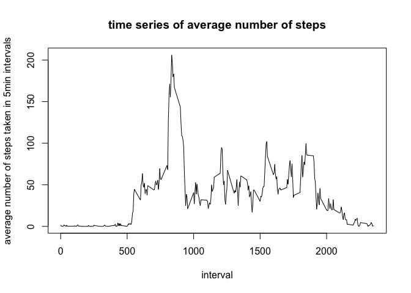

```r
activity_timeseries <- activity %>%
                      na.omit %>%
                      group_by(interval) %>%
                      summarise(mean_steps = mean(steps,na.rm=TRUE))

with(activity_timeseries, plot(interval,mean_steps,type='l',ylab = 'average number of steps taken in 5min intervals',main='time series of average number of steps'))
```

2. Which 5-minute interval, on average across all the days in the dataset, contains the maximum number of steps?

```r
activity_timeseries$interval[which.max(activity_timeseries$mean_steps)]
```

```
## [1] 835
```

## Imputing missing values

1. Calculate and report the total number of missing values in the dataset (i.e. the total number of rows with `NA`s)

```r
sum(is.na(activity$steps))
```

```
## [1] 2304
```

2. Devise a strategy for filling in all of the missing values in the dataset. The strategy does not need to be sophisticated. For example, you could use the mean/median for that day, or the mean for that 5-minute interval, etc.
3. Create a new dataset that is equal to the original dataset but with the missing data filled in.

```r
activity_nareplace <- activity %>%
                      group_by(interval) %>%
                      mutate_at('steps',function(x) replace(x, is.na(x), mean(x,na.rm=TRUE)))
```

4. Make a histogram of the total number of steps taken each day and Calculate and report the **mean** and **median** total number of steps taken per day. Do these values differ from the estimates from the first part of the assignment? What is the impact of imputing missing data on the estimates of the total daily number of steps?

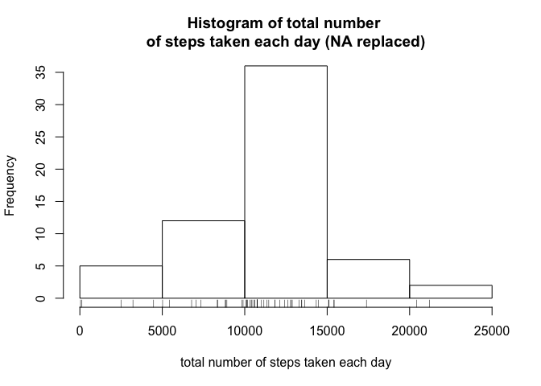

```r
activity_dailytotal2<- activity_nareplace %>%
                      group_by(date) %>%
                      summarise(total = sum(steps)) %>%
                      ungroup(activity_nareplace)

hist(activity_dailytotal2$total,xlab = 'total number of steps taken each day',main = 'Histogram of total number \nof steps taken each day (NA replaced)',ylim=c(0,35))
rug(activity_dailytotal2$total)
```

```r
summary(activity_dailytotal2$total)
```

```
##    Min. 1st Qu.  Median    Mean 3rd Qu.    Max.
##      41    9819   10766   10766   12811   21194
```

## Are there differences in activity patterns between weekdays and weekends?

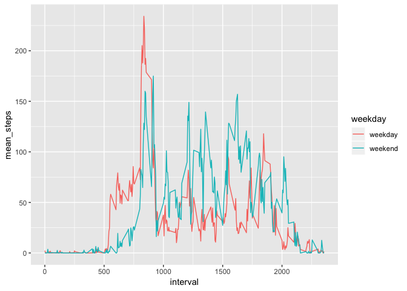

```r
weekday<-weekdays(activity$date)
activity$weekday[(weekday!='Saturday') & (weekday!='Sunday')]<-'weekday'
activity$weekday[(weekday =='Saturday') | (weekday =='Sunday')]<-'weekend'

activity_timeseries_wd <- activity %>%
                      na.omit %>%
                      group_by(interval,weekday) %>%
                      summarise(mean_steps = mean(steps,rm.na=TRUE))
library(ggplot2)
p<-ggplot(data=activity_timeseries_wd,aes(x=interval,y=mean_steps,color=weekday))
p+geom_line()
```